# T02 - EDA Millas por Galón

Distribución de frecuencias para datos agrupados: dataset Auto (ISLR2)

**Ver código: paquetes, datos y configuración**

```r
library(ISLR2)
library(dplyr)
library(tidyr)
library(ggplot2)

data("Auto")

theme_set(theme_minimal(base_size = 12))
options(knitr.kable.NA = "-")

etiqueta_mpg <- "Rendimiento (millas/galón)"
colores_origen <- c("EE. UU." = "#0072B2", "Europa" = "#E69F00", "Japón" = "#009E73")

# origin viene codificado (1 = EE. UU., 2 = Europa, 3 = Japón) y se convierte a factor.
# cylinders se trata como factor ordinal para los gráficos.
autos <- Auto |>
  as_tibble() |>
  mutate(
    origen = factor(origin, levels = 1:3, labels = names(colores_origen)),
    cilindros = factor(cylinders, levels = c(3, 4, 5, 6, 8)),
    anio = 1900 + year
  )

dos_decimales <- function(valor) formatC(valor, format = "f", digits = 2)
```

# Reconocimiento del dataset

El objetivo es construir e interpretar una tabla de distribución de frecuencias para datos agrupados por intervalos de clase, con el dataset `Auto` del paquete ISLR2. La paleta de colores por país de origen (Okabe-Ito, apta para daltonismo) es la misma en todos los gráficos.

| Variable | Tipo | Descripción | Unidad |
| --- | --- | --- | --- |
| `mpg` | Cuantitativa continua | Rendimiento de combustible | millas/galón |
| `cylinders` | Cualitativa ordinal | Número de cilindros | - |
| `displacement` | Cuantitativa continua | Cilindrada del motor | pulg³ |
| `horsepower` | Cuantitativa continua | Potencia | hp |
| `weight` | Cuantitativa continua | Peso del vehículo | lb |
| `acceleration` | Cuantitativa continua | Aceleración 0-60 mph | s |
| `year` | Cualitativa ordinal (temporal) | Año del modelo (70-82) | año |
| `origin` | Cualitativa nominal | País de origen (1, 2, 3) | - |
| `name` | Cualitativa nominal | Nombre del auto | - |

En ISLR2 la columna del año se llama `year` y `origin` viene codificada numéricamente.

**Ver código**

```r
dim(Auto)
```

```
[1] 392   9
```

**Ver código**

```r
glimpse(Auto)
```

```
Rows: 392
Columns: 9
$ mpg          <dbl> 18, 15, 18, 16, 17, 15, 14, 14, 14, 15, 15, 14, 15, 14, 2…
$ cylinders    <int> 8, 8, 8, 8, 8, 8, 8, 8, 8, 8, 8, 8, 8, 8, 4, 6, 6, 6, 4, …
$ displacement <dbl> 307, 350, 318, 304, 302, 429, 454, 440, 455, 390, 383, 34…
$ horsepower   <int> 130, 165, 150, 150, 140, 198, 220, 215, 225, 190, 170, 16…
$ weight       <int> 3504, 3693, 3436, 3433, 3449, 4341, 4354, 4312, 4425, 385…
$ acceleration <dbl> 12.0, 11.5, 11.0, 12.0, 10.5, 10.0, 9.0, 8.5, 10.0, 8.5, …
$ year         <int> 70, 70, 70, 70, 70, 70, 70, 70, 70, 70, 70, 70, 70, 70, 7…
$ origin       <int> 1, 1, 1, 1, 1, 1, 1, 1, 1, 1, 1, 1, 1, 1, 3, 1, 1, 1, 3, …
$ name         <fct> chevrolet chevelle malibu, buick skylark 320, plymouth sa…
```

**Ver código**

```r
names(select(Auto, where(is.numeric)))
```

```
[1] "mpg"          "cylinders"    "displacement" "horsepower"   "weight"
[6] "acceleration" "year"         "origin"
```

**Ver código**

```r
colSums(is.na(Auto))
```

```
         mpg    cylinders displacement   horsepower       weight acceleration
           0            0            0            0            0            0
        year       origin         name
           0            0            0
```

[output not shown]

# Paso 1: Selección de la variable

**Variable elegida:** `mpg` (rendimiento de combustible, millas/galón).

Es cuantitativa continua, no tiene valores nulos y se interpreta de forma directa: a mayor valor de `mpg`, mayor eficiencia del vehículo.

# Paso 2: Medidas descriptivas previas

**Ver código**

```r
mpg <- autos$mpg

n <- length(mpg)
minimo <- min(mpg)
maximo <- max(mpg)
rango <- maximo - minimo
media <- mean(mpg)
mediana <- median(mpg)
desviacion <- sd(mpg) # muestral (n - 1)
coeficiente_variacion <- desviacion / media * 100

medidas_descriptivas <- tibble(
  medida = c("n (tamaño de muestra)", "Mínimo", "Máximo", "Rango (R)", "Media (x̄)",
             "Mediana", "Desviación estándar (s)", "Coeficiente de variación (CV %)"),
  valor = c(n, minimo, maximo, rango, media, mediana, desviacion, coeficiente_variacion)
)

knitr::kable(medidas_descriptivas, digits = 2, col.names = c("Medida", "Valor"))
```

| Medida | Valor |
| --- | --- |
| n (tamaño de muestra) | 392.00 |
| Mínimo | 9.00 |
| Máximo | 46.60 |
| Rango (R) | 37.60 |
| Media (x̄) | 23.45 |
| Mediana | 22.75 |
| Desviación estándar (s) | 7.81 |
| Coeficiente de variación (CV %) | 33.29 |

**Interpretación**

- El auto menos eficiente rinde 9.00 mpg y el más eficiente 46.60 mpg, un rango de 37.60 mpg.
- La media (23.45) y la mediana (22.75) son cercanas; la media es algo mayor, lo que indica un leve sesgo a la derecha.
- La desviación estándar es 7.81 mpg: es la distancia típica de un auto a la media.
- El CV es 33.29 %, mayor a 30 %, por lo que la dispersión es alta y la flota es heterogénea.
- Se usó la desviación muestral (n - 1) porque los 392 autos son una muestra.

# Tabla de distribución de frecuencias (datos agrupados)

- Número de clases (Sturges): k = 1 + 3.322 · log10(392) = 9.61, se usan 10 clases.
- Amplitud: 37.6 / 10 = 3.76, se redondea hacia arriba a 4 mpg.
- El primer límite es el mínimo (9) y los intervalos son cerrados a la izquierda: [Li, Ls).

**Ver código**

```r
k_sturges <- 1 + 3.322 * log10(n)
numero_clases <- round(k_sturges)
amplitud <- ceiling(rango / numero_clases)
limites <- minimo + amplitud * 0:numero_clases

intervalos <- cut(mpg, breaks = limites, right = FALSE)

tabla_frecuencias <- tibble(
  intervalo = levels(intervalos),
  limite_inferior = head(limites, -1),
  limite_superior = tail(limites, -1),
  marca_clase = (limite_inferior + limite_superior) / 2,
  f = as.vector(table(intervalos))
) |>
  mutate(
    fr = f / n,
    fr_porcentaje = fr * 100,
    fa = cumsum(f),
    fa_porcentaje = fa / n * 100
  )

knitr::kable(
  tabla_frecuencias,
  digits = c(0, 0, 0, 0, 0, 4, 2, 0, 2),
  col.names = c("Intervalo", "Límite inferior", "Límite superior", "Marca de clase",
                "f", "fr", "fr %", "fa", "fa %")
)
```

| Intervalo | Límite inferior | Límite superior | Marca de clase | f | fr | fr % | fa | fa % |
| --- | --- | --- | --- | --- | --- | --- | --- | --- |
| [9,13) | 9 | 13 | 11 | 13 | 0.0332 | 3.32 | 13 | 3.32 |
| [13,17) | 13 | 17 | 15 | 79 | 0.2015 | 20.15 | 92 | 23.47 |
| [17,21) | 17 | 21 | 19 | 79 | 0.2015 | 20.15 | 171 | 43.62 |
| [21,25) | 21 | 25 | 23 | 55 | 0.1403 | 14.03 | 226 | 57.65 |
| [25,29) | 25 | 29 | 27 | 63 | 0.1607 | 16.07 | 289 | 73.72 |
| [29,33) | 29 | 33 | 31 | 51 | 0.1301 | 13.01 | 340 | 86.73 |
| [33,37) | 33 | 37 | 35 | 30 | 0.0765 | 7.65 | 370 | 94.39 |
| [37,41) | 37 | 41 | 39 | 15 | 0.0383 | 3.83 | 385 | 98.21 |
| [41,45) | 41 | 45 | 43 | 6 | 0.0153 | 1.53 | 391 | 99.74 |
| [45,49) | 45 | 49 | 47 | 1 | 0.0026 | 0.26 | 392 | 100.00 |

Control de la tabla: k de Sturges = 9.61 y se usan 10 clases de amplitud 4 mpg. La suma de f es 392, la suma de fr es 1 y el último fa % es 100.

Leyenda de columnas:

- **Marca de clase:** punto medio del intervalo.
- **f:** frecuencia absoluta.
- **fr y fr %:** frecuencia relativa (proporción y porcentaje).
- **fa:** frecuencia acumulada.
- **fa %:** porcentaje acumulado.

# Paso 3: Visualización

## Histograma

Usa los mismos límites de la tabla, por lo que coincide exactamente con ella.

**Ver código**

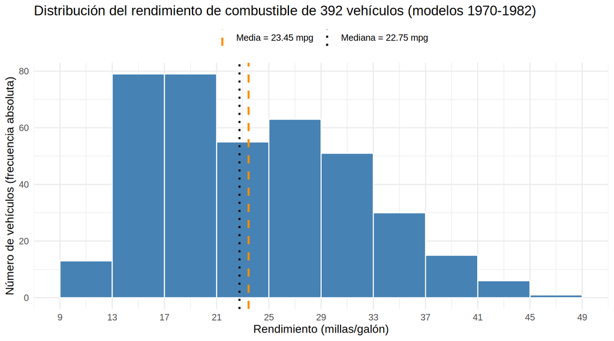

Figura 1: Distribución del rendimiento de combustible con las líneas de la media y la mediana.

```r
lineas_referencia <- tibble(
  medida = c(sprintf("Media = %.2f mpg", media), sprintf("Mediana = %.2f mpg", mediana)),
  valor = c(media, mediana)
)

histograma_mpg <- ggplot(autos, aes(x = mpg)) +
  geom_histogram(breaks = limites, closed = "left", fill = "steelblue", color = "white") +
  geom_vline(data = lineas_referencia,
             aes(xintercept = valor, linetype = medida, color = medida), linewidth = 1) +
  scale_color_manual(values = c("darkorange", "black")) +
  scale_linetype_manual(values = c("dashed", "dotted")) +
  scale_x_continuous(breaks = limites) +
  labs(title = "Distribución del rendimiento de combustible de 392 vehículos (modelos 1970-1982)",
       x = etiqueta_mpg, y = "Número de vehículos (frecuencia absoluta)",
       color = NULL, linetype = NULL) +
  theme(legend.position = "top")
print(histograma_mpg)
```

## Ojiva

El porcentaje acumulado se grafica contra el límite superior de cada intervalo, iniciando en 0 % en el primer límite.

**Ver código**

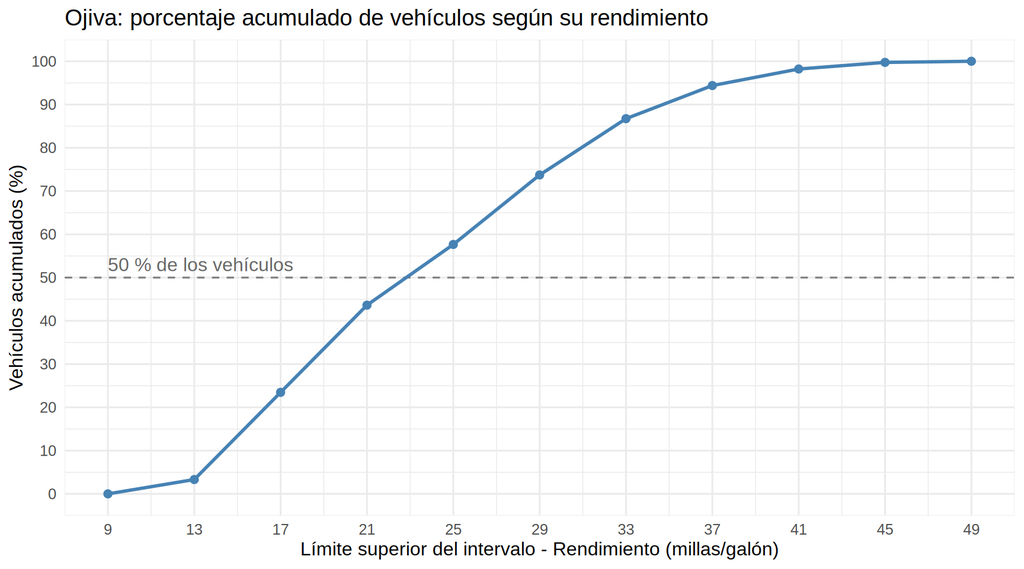

Figura 2: Ojiva del porcentaje acumulado de vehículos según su rendimiento.

```r
datos_ojiva <- tibble(limite = limites, porcentaje_acumulado = c(0, tabla_frecuencias$fa_porcentaje))

ojiva_mpg <- ggplot(datos_ojiva, aes(x = limite, y = porcentaje_acumulado)) +
  geom_hline(yintercept = 50, linetype = "dashed", color = "gray50") +
  geom_line(color = "steelblue", linewidth = 1) +
  geom_point(color = "steelblue", size = 2) +
  annotate("text", x = minimo, y = 53, label = "50 % de los vehículos", hjust = 0, color = "gray40") +
  scale_x_continuous(breaks = limites) +
  scale_y_continuous(limits = c(0, 100), breaks = seq(0, 100, 10)) +
  labs(title = "Ojiva: porcentaje acumulado de vehículos según su rendimiento",
       x = paste("Límite superior del intervalo -", etiqueta_mpg),
       y = "Vehículos acumulados (%)")
print(ojiva_mpg)
```

## Diagrama de caja y valores atípicos

**Ver código**

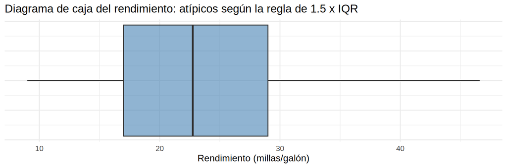

Figura 3: Diagrama de caja del rendimiento de combustible.

```r
caja_mpg <- ggplot(autos, aes(x = mpg)) +
  geom_boxplot(fill = "steelblue", alpha = 0.6) +
  labs(title = "Diagrama de caja del rendimiento: atípicos según la regla de 1.5 x IQR",
       x = etiqueta_mpg, y = NULL) +
  theme(axis.text.y = element_blank(), axis.ticks.y = element_blank())
print(caja_mpg)
```

**Ver código**

```r
coeficiente_asimetria <- function(valores) {
  desviaciones <- valores - mean(valores)
  mean(desviaciones^3) / mean(desviaciones^2)^1.5
}

primer_cuartil <- unname(quantile(mpg, 0.25))
tercer_cuartil <- unname(quantile(mpg, 0.75))
rango_intercuartil <- tercer_cuartil - primer_cuartil
limite_inferior_atipicos <- primer_cuartil - 1.5 * rango_intercuartil
limite_superior_atipicos <- tercer_cuartil + 1.5 * rango_intercuartil
valores_atipicos <- mpg[mpg < limite_inferior_atipicos | mpg > limite_superior_atipicos]

tibble(
  medida = c("Q1", "Q3", "IQR", "Límite inferior para atípicos", "Límite superior para atípicos",
             "Cantidad de valores atípicos", "Coeficiente de asimetría"),
  valor = c(primer_cuartil, tercer_cuartil, rango_intercuartil, limite_inferior_atipicos,
            limite_superior_atipicos, length(valores_atipicos), coeficiente_asimetria(mpg))
) |>
  knitr::kable(digits = 3, col.names = c("Medida", "Valor"))
```

| Medida | Valor |
| --- | --- |
| Q1 | 17.000 |
| Q3 | 29.000 |
| IQR | 12.000 |
| Límite inferior para atípicos | -1.000 |
| Límite superior para atípicos | 47.000 |
| Cantidad de valores atípicos | 0.000 |
| Coeficiente de asimetría | 0.455 |

**Análisis de la forma de la distribución**

- **¿Es simétrica o sesgada?** Sesgada a la derecha (positiva) de forma moderada: la media (23.45) es mayor que la mediana (22.75) y la asimetría es 0.455.
- **¿Hacia qué lado se concentra la mayor frecuencia?** Hacia la izquierda y el centro-izquierda: los intervalos [13, 17) y [17, 21) empatan con 79 autos cada uno (40.31 % entre los dos) y la cola se extiende hacia los valores altos de mpg.
- **¿Hay valores atípicos visibles?** No según la regla de 1.5 x IQR (límites de -1 a 47). El valor más alto (46.6 mpg) queda cerca del límite superior, pero dentro.

# Paso 4: Interpretación de resultados

**Contexto de la variable**

- `mpg` mide las millas que recorre un auto con un galón de combustible.
- Un valor mayor significa mayor eficiencia.
- El análisis cubre 392 autos con modelos de 1970 a 1982.

**Tendencia central**

- La media (23.45 mpg) y la mediana (22.75 mpg) son cercanas; difieren en 0.70 mpg.
- La media es mayor porque la cola derecha, con autos muy eficientes, la jala hacia arriba.

**Dispersión**

- La desviación estándar es 7.81 mpg y el rango es 37.60 mpg.
- El CV de 33.29 % supera el 30 %, así que la variabilidad es alta.
- La media representa al conjunto solo con cautela, porque hay autos muy distintos entre sí.

**Distribución de frecuencias y acumulados**

- Hay dos clases modales empatadas: [13, 17) y [17, 21), con 79 autos (20.15 % cada una).
- 171 autos (43.62 %) rinden menos de 21 mpg y el 57.65 % rinde menos de 25 mpg.
- En la ojiva el 50 % se alcanza dentro de [21, 25), coherente con la mediana de 22.75.

**Conclusión general**

- Predominan los autos de rendimiento bajo a medio.
- Un grupo minoritario de autos muy eficientes produce el sesgo a la derecha.
- La alta heterogeneidad sugiere subgrupos (cilindros, origen, año) que se estudian en el Paso 6.

# Paso 5: Preguntas de reflexión

**¿Qué información aporta la ojiva que no aporta el histograma?**

- La ojiva permite leer directamente porcentajes acumulados y percentiles.
- Por ejemplo, el 43.62 % de los autos rinde menos de 21 mpg y la mitad rinde menos de unos 23 mpg.
- El histograma muestra la frecuencia de cada intervalo y la forma de la distribución, pero no acumula, así que esas lecturas exigen sumar barras a mano.

**Si tuviera que comparar dos modelos de autos (por ejemplo, 4 contra 8 cilindros), ¿cómo usaría las tablas de frecuencia?**

- Filtraría cada grupo (por ejemplo, `filter(cylinders == 4)`) y construiría una tabla por grupo usando los mismos límites de clase.
- Compararía frecuencias relativas y no absolutas, porque los tamaños son distintos (n = 199 contra n = 103).
- Revisaría la clase modal de cada grupo y el porcentaje acumulado en un mismo umbral.
- Superpondría las ojivas de ambos grupos para ver cuál queda a la izquierda.

# Paso 6: Análisis comparativo

**Ver código: funciones auxiliares**

```r
resumir_mpg_por_grupo <- function(datos, columna_grupo) {
  datos |>
    group_by({{ columna_grupo }}) |>
    summarise(
      n = n(),
      media = mean(mpg),
      mediana = median(mpg),
      desviacion = sd(mpg),
      q1 = unname(quantile(mpg, 0.25)),
      q3 = unname(quantile(mpg, 0.75)),
      asimetria = coeficiente_asimetria(mpg),
      .groups = "drop"
    ) |>
    mutate(iqr = q3 - q1)
}

etiquetas_con_n <- function(datos, columna_grupo) {
  conteos <- count(datos, {{ columna_grupo }})
  grupos <- as.character(pull(conteos, {{ columna_grupo }}))
  setNames(paste0(grupos, "\n(n = ", conteos$n, ")"), grupos)
}

nombres_resumen <- c("n", "Media", "Mediana", "Desv. estándar", "Q1", "Q3", "Asimetría", "IQR")
```

## Pregunta 1: ¿Existen diferencias en el rendimiento (mpg) según el número de cilindros?

**Tipo de análisis:** comparación entre grupos.

**Ver código**

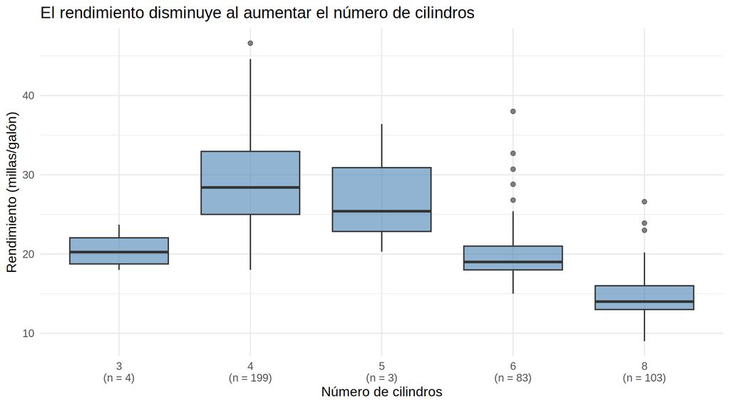

Figura 4: Rendimiento por número de cilindros.

```r
caja_por_cilindros <- ggplot(autos, aes(x = cilindros, y = mpg)) +
  geom_boxplot(fill = "steelblue", alpha = 0.6) +
  scale_x_discrete(labels = etiquetas_con_n(autos, cilindros)) +
  labs(title = "El rendimiento disminuye al aumentar el número de cilindros",
       x = "Número de cilindros", y = etiqueta_mpg)
print(caja_por_cilindros)
```

**Ver código**

```r
resumir_mpg_por_grupo(autos, cilindros) |>
  knitr::kable(digits = 2, col.names = c("Cilindros", nombres_resumen))
```

| Cilindros | n | Media | Mediana | Desv. estándar | Q1 | Q3 | Asimetría | IQR |
| --- | --- | --- | --- | --- | --- | --- | --- | --- |
| 3 | 4 | 20.55 | 20.25 | 2.56 | 18.75 | 22.05 | 0.27 | 3.30 |
| 4 | 199 | 29.28 | 28.40 | 5.67 | 25.00 | 32.95 | 0.53 | 7.95 |
| 5 | 3 | 27.37 | 25.40 | 8.23 | 22.85 | 30.90 | 0.41 | 8.05 |
| 6 | 83 | 19.97 | 19.00 | 3.83 | 18.00 | 21.00 | 2.09 | 3.00 |
| 8 | 103 | 14.96 | 14.00 | 2.84 | 13.00 | 16.00 | 1.17 | 3.00 |

**Preguntas de interpretación**

- **¿Cómo varía la mediana al aumentar los cilindros?** Baja: 28.40 (4 cilindros), 19.00 (6) y 14.00 (8). Los autos de 3 y 5 cilindros rompen la tendencia, pero solo hay 4 y 3 autos, por lo que no son confiables (los de 3 cilindros son motores rotativos).
- **¿Qué grupo tiene mayor dispersión?** Entre los grupos con n suficiente, el de 4 cilindros (s = 5.67, IQR = 7.95), probablemente por mezclar orígenes, años, compactos muy eficientes y autos diésel. El de 5 cilindros tiene una s mayor, pero con solo 3 autos.
- **¿Hay solapamiento entre las cajas?** La caja de 4 cilindros (25.00 a 32.95) no se solapa con la de 6 (18.00 a 21.00) ni con la de 8 (13.00 a 16.00), y las de 6 y 8 tampoco entre sí. Poco solapamiento sugiere diferencias de medias probablemente significativas.
- **Hipótesis para ANOVA:** H0: μ3 = μ4 = μ5 = μ6 = μ8 (las medias de mpg son iguales); H1: al menos una media difiere.

**NotaInterpretación técnica**

- Existe una relación inversa clara entre cilindros y rendimiento en los grupos grandes.
- La mediana pasa de 28.40 mpg con 4 cilindros a 14.00 mpg con 8 cilindros.
- Los grupos de 3 y 5 cilindros son demasiado pequeños para concluir algo.
- Antes de aplicar ANOVA convendría agrupar o excluir esas categorías.
- También habría que revisar supuestos: normalidad y varianzas similares (s va de 2.84 a 5.67).
- Esta comparación no controla otras variables como peso u origen, que se revisan a continuación.

## Pregunta 2: ¿Existen diferencias significativas en el rendimiento según el país de origen?

**Tipo de análisis:** comparación entre grupos.

**Ver código**

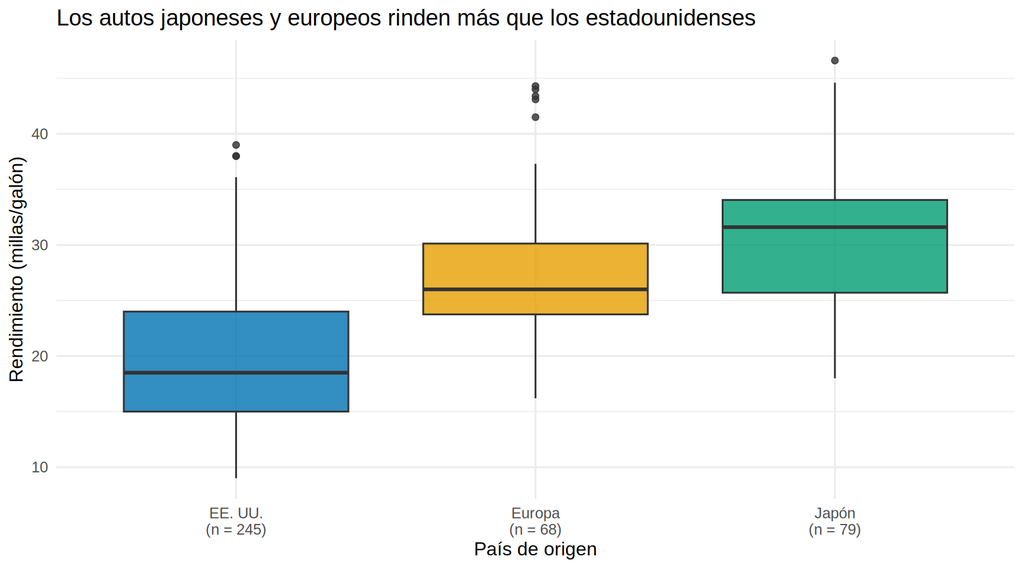

Figura 5: Rendimiento por país de origen.

```r
caja_por_origen <- ggplot(autos, aes(x = origen, y = mpg, fill = origen)) +
  geom_boxplot(alpha = 0.8) +
  scale_fill_manual(values = colores_origen, guide = "none") +
  scale_x_discrete(labels = etiquetas_con_n(autos, origen)) +
  labs(title = "Los autos japoneses y europeos rinden más que los estadounidenses",
       x = "País de origen", y = etiqueta_mpg)
print(caja_por_origen)
```

**Ver código**

```r
resumir_mpg_por_grupo(autos, origen) |>
  knitr::kable(digits = 2, col.names = c("Origen", nombres_resumen))
```

| Origen | n | Media | Mediana | Desv. estándar | Q1 | Q3 | Asimetría | IQR |
| --- | --- | --- | --- | --- | --- | --- | --- | --- |
| EE. UU. | 245 | 20.03 | 18.5 | 6.44 | 15.00 | 24.00 | 0.84 | 9.00 |
| Europa | 68 | 27.60 | 26.0 | 6.58 | 23.75 | 30.12 | 0.75 | 6.38 |
| Japón | 79 | 30.45 | 31.6 | 6.09 | 25.70 | 34.05 | 0.01 | 8.35 |

Promedio de peso, potencia y cilindrada por origen (posibles variables de confusión):

**Ver código**

```r
autos |>
  group_by(origen) |>
  summarise(across(c(weight, horsepower, displacement), \(valor) round(mean(valor)))) |>
  knitr::kable(col.names = c("Origen", "Peso (lb)", "Potencia (hp)", "Cilindrada (pulg³)"))
```

| Origen | Peso (lb) | Potencia (hp) | Cilindrada (pulg³) |
| --- | --- | --- | --- |
| EE. UU. | 3372 | 119 | 248 |
| Europa | 2433 | 81 | 110 |
| Japón | 2221 | 80 | 103 |

**Preguntas de interpretación**

- **¿Qué origen rinde mejor y cuál peor?** Mejor Japón (30.45 mpg de media) y peor EE. UU. (20.03 mpg); Europa queda en 27.60 mpg.
- **¿Es similar la forma de las distribuciones?** No del todo: EE. UU. (asimetría 0.84) y Europa (0.75) están sesgados a la derecha, y Japón es casi simétrico (0.01).
- **¿Hay igualdad de varianzas?** Parece razonable: las desviaciones son 6.44 (EE. UU.), 6.58 (Europa) y 6.09 (Japón); la razón entre la mayor y la menor es cercana a 1.08. Se confirmaría con una prueba de Levene o Bartlett.
- **¿Qué variables de confusión hay?** El peso (3372 lb en EE. UU. contra 2433 y 2221 lb), la potencia, la cilindrada, el número de cilindros (solo EE. UU. tiene autos de 8 cilindros) y el año del modelo.

**NotaInterpretación técnica**

- Japón tiene el mejor rendimiento medio y EE. UU. el peor, con una diferencia de 10.42 mpg.
- Las formas difieren, pero las dispersiones son parecidas, lo que apoya comparar medias.
- Los autos estadounidenses son más pesados, potentes y de motor más grande.
- Por eso la diferencia entre orígenes no puede atribuirse al país por sí solo.
- Primero hay que controlar peso, cilindros y año antes de hablar de un efecto del origen.
- Una prueba formal (ANOVA o Kruskal-Wallis) cuantificaría si la diferencia es significativa.

## Pregunta 3: ¿Cómo interactúan el origen y el número de cilindros sobre el rendimiento?

**Tipo de análisis:** comparación multivariada categórica.

**Ver código**

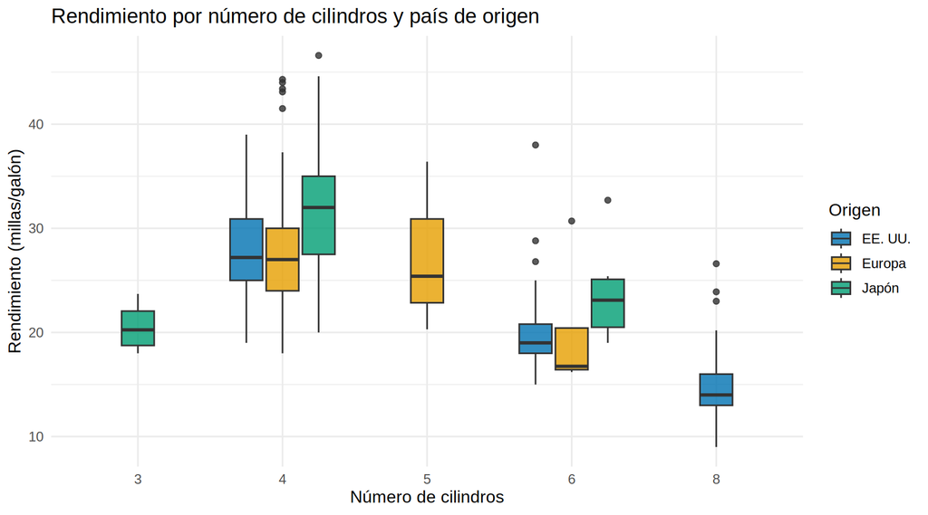

Figura 6: Rendimiento por número de cilindros y país de origen.

```r
caja_cilindros_origen <- ggplot(autos, aes(x = cilindros, y = mpg, fill = origen)) +
  geom_boxplot(position = position_dodge2(preserve = "single"), alpha = 0.8) +
  scale_fill_manual(values = colores_origen) +
  labs(title = "Rendimiento por número de cilindros y país de origen",
       x = "Número de cilindros", y = etiqueta_mpg, fill = "Origen")
print(caja_cilindros_origen)
```

Número de autos por combinación:

**Ver código**

```r
autos |>
  count(cilindros, origen) |>
  pivot_wider(names_from = origen, values_from = n, values_fill = 0) |>
  select(cilindros, all_of(names(colores_origen))) |>
  knitr::kable(col.names = c("Cilindros", names(colores_origen)))
```

| Cilindros | EE. UU. | Europa | Japón |
| --- | --- | --- | --- |
| 3 | 0 | 0 | 4 |
| 4 | 69 | 61 | 69 |
| 5 | 0 | 3 | 0 |
| 6 | 73 | 4 | 6 |
| 8 | 103 | 0 | 0 |

Rendimiento medio (mpg) por combinación:

**Ver código**

```r
autos |>
  group_by(cilindros, origen) |>
  summarise(media = round(mean(mpg), 1), .groups = "drop") |>
  pivot_wider(names_from = origen, values_from = media) |>
  select(cilindros, all_of(names(colores_origen))) |>
  knitr::kable(col.names = c("Cilindros", names(colores_origen)))
```

| Cilindros | EE. UU. | Europa | Japón |
| --- | --- | --- | --- |
| 3 | - | - | 20.6 |
| 4 | 28.0 | 28.1 | 31.6 |
| 5 | - | 27.4 | - |
| 6 | 19.6 | 20.1 | 23.9 |
| 8 | 15.0 | - | - |

**Preguntas de interpretación**

- **¿Es constante el efecto de los cilindros entre orígenes?** Es constante en dirección: más cilindros, menos mpg. Con 4 cilindros: Japón 31.6, Europa 28.1 y EE. UU. 28.0; con 6 cilindros: Japón 23.9, Europa 20.1 y EE. UU. 19.6.
- **¿Algún origen se comporta distinto?** Solo EE. UU. tiene autos de 8 cilindros (15.0 mpg); solo Japón tiene de 3 y solo Europa de 5. Japón queda por encima en cada nivel comparable.
- **¿Qué ventaja tiene este gráfico?** Controla una segunda variable a la vez.

**NotaInterpretación técnica**

- El efecto de los cilindros sigue la misma dirección en todos los orígenes.
- La brecha entre EE. UU. y Japón es de 10.42 mpg en general, pero baja a unos 3.6 mpg dentro de los autos de 4 cilindros.
- Así, buena parte de la diferencia por origen se explica por la mezcla de cilindros.
- Con 4 cilindros, EE. UU. y Europa tienen medias prácticamente iguales.
- El diseño es incompleto (hay combinaciones sin autos), lo que impide evaluar la interacción completa entre origen y cilindros.
- La ventaja del gráfico es que revela una confusión que los gráficos de las preguntas 1 y 2 ocultan.

## Pregunta 4: ¿Cómo ha cambiado la composición de cilindros y orígenes por año?

**Tipo de análisis:** composición por categorías en el tiempo.

**Ver código**

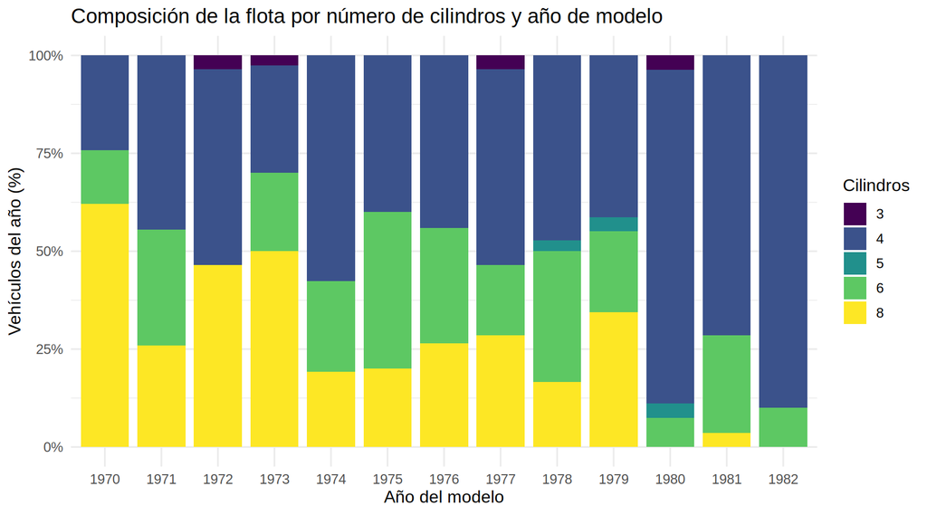

Figura 7: Composición de la flota por número de cilindros y año de modelo.

```r
composicion_cilindros <- ggplot(autos, aes(x = factor(anio), fill = cilindros)) +
  geom_bar(position = "fill", width = 0.85) +
  scale_y_continuous(labels = scales::label_percent()) +
  scale_fill_viridis_d() +
  labs(title = "Composición de la flota por número de cilindros y año de modelo",
       x = "Año del modelo", y = "Vehículos del año (%)", fill = "Cilindros")
print(composicion_cilindros)
```

**Ver código**

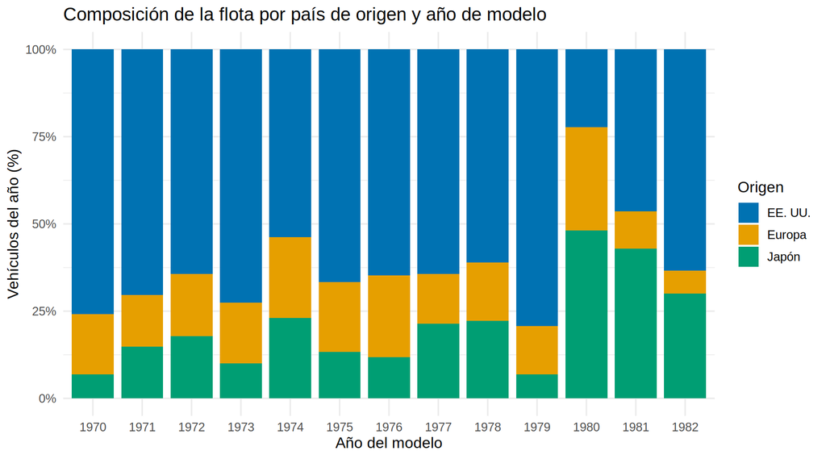

Figura 8: Composición de la flota por país de origen y año de modelo.

```r
composicion_origen <- ggplot(autos, aes(x = factor(anio), fill = origen)) +
  geom_bar(position = "fill", width = 0.85) +
  scale_y_continuous(labels = scales::label_percent()) +
  scale_fill_manual(values = colores_origen) +
  labs(title = "Composición de la flota por país de origen y año de modelo",
       x = "Año del modelo", y = "Vehículos del año (%)", fill = "Origen")
print(composicion_origen)
```

**Ver código**

```r
autos |>
  group_by(anio) |>
  summarise(
    mpg_medio = mean(mpg),
    porcentaje_8_cilindros = mean(cylinders == 8) * 100,
    porcentaje_ee_uu = mean(origen == "EE. UU.") * 100,
    porcentaje_japon = mean(origen == "Japón") * 100
  ) |>
  knitr::kable(
    digits = 1,
    col.names = c("Año", "mpg medio", "% autos de 8 cilindros", "% autos de EE. UU.", "% autos de Japón")
  )
```

| Año | mpg medio | % autos de 8 cilindros | % autos de EE. UU. | % autos de Japón |
| --- | --- | --- | --- | --- |
| 1970 | 17.7 | 62.1 | 75.9 | 6.9 |
| 1971 | 21.1 | 25.9 | 70.4 | 14.8 |
| 1972 | 18.7 | 46.4 | 64.3 | 17.9 |
| 1973 | 17.1 | 50.0 | 72.5 | 10.0 |
| 1974 | 22.8 | 19.2 | 53.8 | 23.1 |
| 1975 | 20.3 | 20.0 | 66.7 | 13.3 |
| 1976 | 21.6 | 26.5 | 64.7 | 11.8 |
| 1977 | 23.4 | 28.6 | 64.3 | 21.4 |
| 1978 | 24.1 | 16.7 | 61.1 | 22.2 |
| 1979 | 25.1 | 34.5 | 79.3 | 6.9 |
| 1980 | 33.8 | 0.0 | 22.2 | 48.1 |
| 1981 | 30.2 | 3.6 | 46.4 | 42.9 |
| 1982 | 32.0 | 0.0 | 63.3 | 30.0 |

**Preguntas de interpretación**

- **¿Cómo evolucionó la participación de cada origen?** EE. UU. domina hasta 1979 (entre 53.8 % y 79.3 %), cae a 22.2 % en 1980 y Japón sube a 48.1 % ese año y a 42.9 % en 1981.
- **¿Disminuyeron los autos de 8 cilindros?** Sí: pasan de 62.1 % en 1970 a 0 % en 1980 y 1982, aunque con altibajos (por ejemplo, 34.5 % en 1979).
- **¿Qué relación tiene con la tendencia de mpg?** El mpg medio sube de 17.7 (1970) a 33.8 (1980) y 32.0 (1982), en paralelo con menos autos de 8 cilindros y más autos japoneses.

**NotaInterpretación técnica**

- EE. UU. domina la muestra hasta 1979 y después pierde peso frente a Japón.
- Los autos de 8 cilindros casi desaparecen desde 1980.
- El aumento del mpg medio coincide con ese cambio de composición.
- Un contexto posible son las crisis del petróleo de 1973 y 1979 y las normas de eficiencia de combustible en EE. UU.
- Se trata de una asociación; estos datos no demuestran que una cosa cause la otra.
- Los tamaños por año son pequeños (entre 26 y 40 autos), así que los porcentajes varían mucho.

# Paso 7: Diseño de mi propio análisis

**Pregunta de análisis propuesta:** ¿cómo se relaciona el peso del vehículo con su rendimiento y cambia esa relación según el país de origen?

**Variables involucradas**

- **Eje X:** `weight` (peso del vehículo, lb).
- **Eje Y:** `mpg` (rendimiento, millas/galón).
- **Color/grupo:** `origen`.

**Tipo de gráfico y justificación**

- Dispersión con una recta de regresión por origen.
- Se comparan dos variables continuas, para lo que la dispersión es el gráfico adecuado.
- La recta por grupo permite comparar pendientes y niveles entre orígenes.

**Ver código**

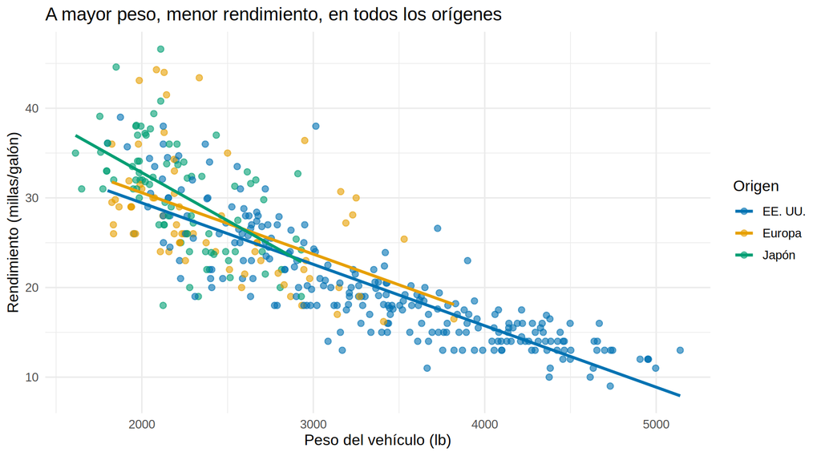

Figura 9: Relación entre peso y rendimiento, por país de origen.

```r
grafico_peso_mpg <- ggplot(autos, aes(x = weight, y = mpg, color = origen)) +
  geom_point(alpha = 0.6, size = 2) +
  geom_smooth(method = "lm", formula = y ~ x, se = FALSE) +
  scale_color_manual(values = colores_origen) +
  labs(title = "A mayor peso, menor rendimiento, en todos los orígenes",
       x = "Peso del vehículo (lb)", y = etiqueta_mpg, color = "Origen")
print(grafico_peso_mpg)
```

**Ver código**

```r
correlaciones_por_origen <- autos |>
  group_by(origen) |>
  summarise(correlacion = cor(weight, mpg))

bind_rows(
  correlaciones_por_origen |> mutate(origen = as.character(origen)),
  tibble(origen = "Todos", correlacion = cor(autos$weight, autos$mpg))
) |>
  knitr::kable(digits = 3, col.names = c("Origen", "Correlación de Pearson peso-mpg"))
```

| Origen | Correlación de Pearson peso-mpg |
| --- | --- |
| EE. UU. | -0.846 |
| Europa | -0.512 |
| Japón | -0.564 |
| Todos | -0.832 |

**NotaInterpretación técnica**

- La relación entre peso y rendimiento es negativa y fuerte (r = -0.832).
- Es aproximadamente lineal, con una ligera curvatura en los pesos bajos.
- Los autos de EE. UU. son los más pesados (3372 lb en promedio) y los de menor mpg; su correlación es la más fuerte (r = -0.846).
- Europa (r = -0.512) y Japón (r = -0.564) se concentran en autos livianos y tienen una correlación moderada, en parte porque el rango de peso es más estrecho.
- El peso actúa como variable de confusión: explica buena parte de la diferencia por origen observada en la pregunta 2.
- Una correlación alta no implica causalidad.
- Un siguiente paso razonable sería una regresión de mpg con peso y origen como predictores.

# Conclusión general

Los 392 autos tienen un rendimiento medio de 23.45 mpg, con alta dispersión (CV de 33.29 %) y un leve sesgo a la derecha. Más cilindros y más peso se asocian con menos mpg. Japón rinde más y EE. UU. menos, pero gran parte de esa diferencia se explica por el peso y la mezcla de cilindros de cada origen. Con los años la flota se volvió más eficiente, en paralelo con la desaparición de los autos de 8 cilindros y el aumento de los japoneses. Estos resultados describen asociaciones en esta muestra y no demuestran causalidad.